# INFORME COYUNTURA PAÍS VASCO

## Resumen ejecutivo

El objetivo de este informe es conseguir analizar los ciclos de la economía vasca en el corto plazo. Además, en qué momento del ciclo se encuentra ésta a través de datos trimestrales, y, en momentos enlos que no se disponían, datos mensuales o anuales.

Modelizaremos dichos datos, observaremos la tendencia, su estacionalidad y las correspondientes tasas de variación. Los indicadores que estudiaremos serán correspondientes a la actividad productiva, como el PIB, IPI e ICE; a la demanda y el mercado de trabajo.

La economía vasca es una de las más industrializadas de España, lo cual lo observaremos en el siguiente análisis. Junto a ello, finalmente se verá su posible recuperación tras la crisis del Covid-19, con predicciones sobre las afiliaciones a la Seguridad Social, el desempleo registrado y la tasa de desempleo.

## Actividad Productiva

Para la actividad productiva veremos distintos índices pudiendo ver el estado actual de la economía vasca respecto al resto de España.

Entre ellos usaremos el PIB, IPI (Índice de Producción Industrial) y ICE (Índice de Confianza Empresarial). Trataremos los datos para que sean más visuales y manejables.

#### · Representación del PIB en volumen, tasa de variación intertrimestral e interanual

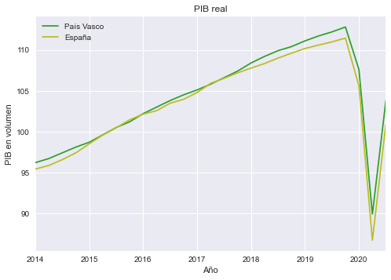

Este gráfico muestra la evolución del PIB en volumen desde el primer trimestre de 2014 hasta el tercer trimestre de 2020. Tanto la serie de España como la del País Vasco están ajustadas a efectos estacionales y de calendario estando en base a 2015. La tendencia de la serie es clara observándose el descenso en el segundo trimestre de 2020 debido a la pandemia del coronavirus junto con una recuperación sustancial en trimestre siguiente; este shock será observable en todas las series posteriores.

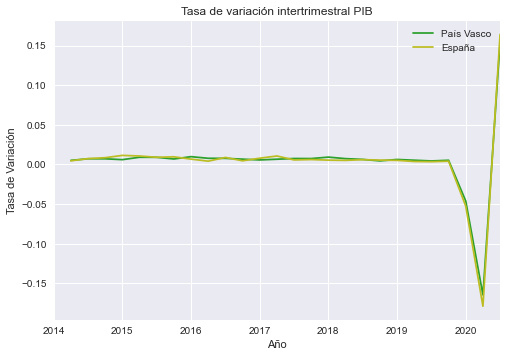

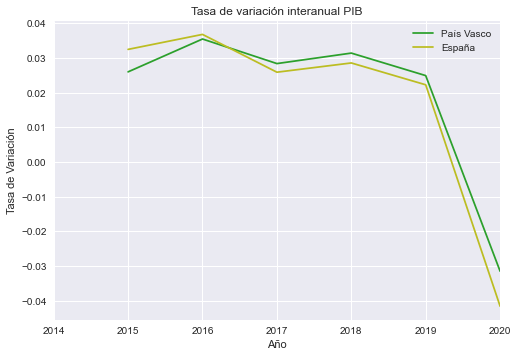

El primer gráfico muestra la tasa de variación del PIB tanto de España como del País Vasco, y la segunda la tasa de variación interanual. En ambos casos las variaciones son muy parecidas, siendo de forma intertrimestral una variabilidad siempre positiva pero muy cercana a cero; mientras que la interanual se mantiene dentro del intervalo del 2% al 4% de crecimiento anual.

Para la tasa de variación intertrimestral se observa el impacto del Covid-19, pudiéndose observar un descenso muy pronunciado, llegando hasta un 17'8% de la caída del PIB respecto al trimestre anterior para España y un 16'5% para el País Vasco, pero una recuperación del mismo llegando a aumentar respecto al trimestre aterior un 16'5% y 15'5% respectivamente.

En la tasa de variación interanual se observa una caída pronunciada, aunque no tan exagerada como en la anterior. En el caso de España el descenso es de un 4'16% mientras que para el País Vasco es de 3'15%.

A conticuación se muestran los datos extraídos de las tablas correspondientes expresados en porcentajes (%):

|  | Tasa de variación intertrimestral España |
| --- | --- |
| 2019-10-01 00:00:00 | 0.41% |
| 2020-01-01 00:00:00 | -5.25% |
| 2020-04-01 00:00:00 | -17.88% |
| 2020-07-01 00:00:00 | 16.41% |

|  | Tasa de variación intertrimestral País Vasco |
| --- | --- |
| 2019-10-01 00:00:00 | 0.53% |
| 2020-01-01 00:00:00 | -4.61% |
| 2020-04-01 00:00:00 | -16.45% |
| 2020-07-01 00:00:00 | 15.46% |

|  | Tasa de variación interanual España |
| --- | --- |
| 2019-01-01 00:00:00 | 2.23% |
| 2020-01-01 00:00:00 | -4.16% |

|  | Tasa de variación interanual País Vasco |
| --- | --- |
| 2019-01-01 00:00:00 | 2.49% |
| 2020-01-01 00:00:00 | -3.15% |

#### ·Evolución IPI original y desestacionalizado

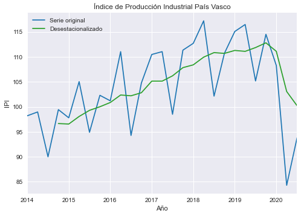

Aquí se muestra la evolución del Índice de Producción Industrial del País Vasco, cuya serie está en base a 2015. Este índice muestra la evolución de la actividad productiva de las distintas ramas industriales.

Como vemos la actividad industrial, a través de éste índice, que va tiene una tendencia clara hasta el momento de la crisis del coronavirus. La serie más suavizada es la desestacionalizada a través de una media móvil de cuatro periodos, ya que hemos trimestralizado los datos.

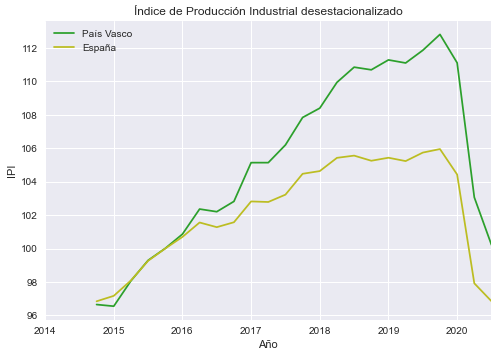

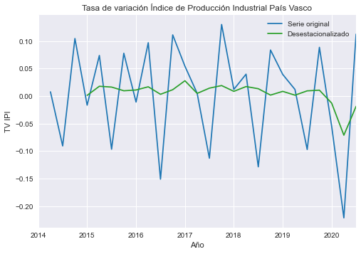

En éste caso observamos la tasa de variación del IPI en el País Vasco, con la serie original y ajustada. El patrón que podemos observar en la serie original es una caida pronunciada en el tercer trimestre, pero una amplia recuperación para el cuarto, manteniéndose hasta los siguientes. En la tasa de variación desestacionalizada vemos que se mantiene en un crecimiento trimestral de alrededor de un 1%, aunque con una caida especialmente pronunciada en 2020.

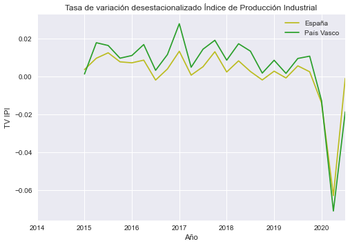

Observando las tasas de variación del IPI desestacionalizado para España y el País Vasco, vemos que la del País Vasco siempre ha sido relativamente mayor, aunque su caída en la crisis también ha sido más pronunciada.

Podemos ver los datos representados en las siguientes tablas:

|  | Tasa de variación IPI País Vasco |
| --- | --- |
| 2019-10-01 00:00:00 | 1.08% |
| 2020-01-01 00:00:00 | -1.26% |
| 2020-04-01 00:00:00 | -7.10% |
| 2020-07-01 00:00:00 | -1.86% |

|  | Tasa de variación IPI España |
| --- | --- |
| 2019-10-01 00:00:00 | 0.26% |
| 2020-01-01 00:00:00 | -1.38% |
| 2020-04-01 00:00:00 | -6.29% |
| 2020-07-01 00:00:00 | -0.09% |

#### ·Representación Índice de Confianza Empresarial

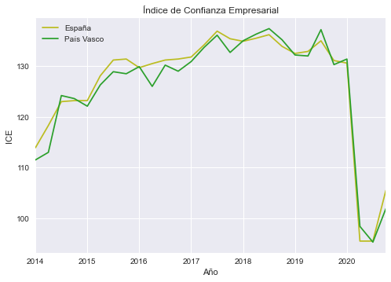

Comparando los Índices de Confianza Empresarial de España y del País Vasco, vemos que su evolución es muy paralela sin grandes diferencias; incluso también con una caída idéntica en la crisis por el Covid-19.

## Demanda

En la demanda veremos el ICC (únicamente disponible para España), ICS (Índice Coyuntural de Servicios) y el estado del comercio exterior en los últimos años del País Vasco comparado con el estado español.

#### ·Representación gráfica Índice de Confianza del Consumidor

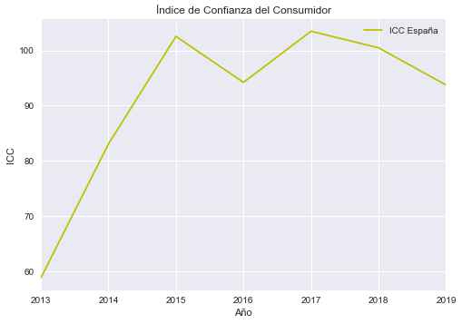

El índice ofrecido por el CIS es a nivel nacional, para el País Vasco no hay datos. Además, son datos anuales.

La evolución de éste vemos la recuperación de la crisis financiera e inmobiliaria del 2008, aunque con un leve descenso en 2019.

#### ·Índice Coyuntural de Servicios

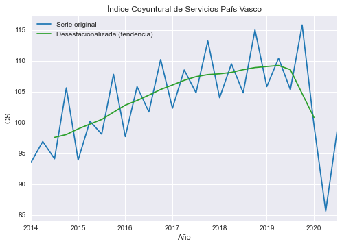

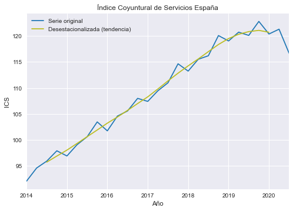

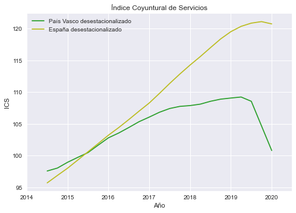

El Índice Coyuntural de Servicios (ICS) mide la evolución de ventas y personal ocupado del sector servicios. Este índice está en base a 2015 para ambas series, y ajustadas a calendario.

Nosotros la hemos desestacionalizado (en éste caso con una descomposición estacional de modelo aditivo) y, como vemos, la evolución de ambas no es similar. En el caso de España es mayor que la del País Vasco, indicándonos que la evolución y crecimiento es mayor en media para España que el País Vasco.

Además, la caída tras la crisis de la pandemia es mayor para el País Vasco que para España.

#### ·Evolución del Comercio Exterior

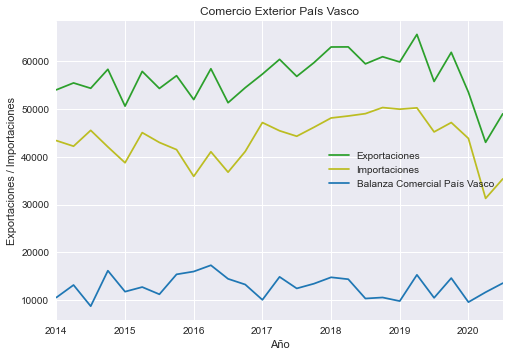

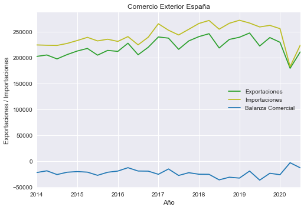

Los últimos dos gráficos muestran el comercio exterior para España y el País Vasco deflactados con el IPC correspondiente al trimestre en sí.

A simple vista se ve el superávit que posee el País Vasco, frente al déficit de España desde hace tiempo. Posteriormente profundizaremos en ello.

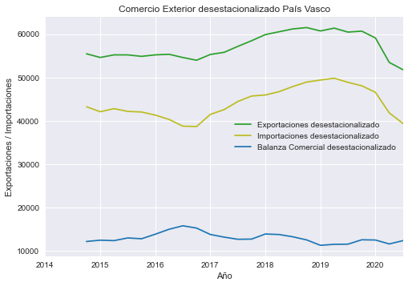

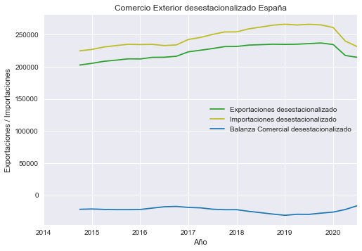

Los últimos gráficos muestran las series originales y desestacionalizadas (también a través de media móvil) de las exportaciones, importaciones y balanza comercial para el País Vasco y España.

En los siguientes observaremos las tasas de variación para las series desestacionalizadas, comparándo simultáneamente el País Vasco y España:

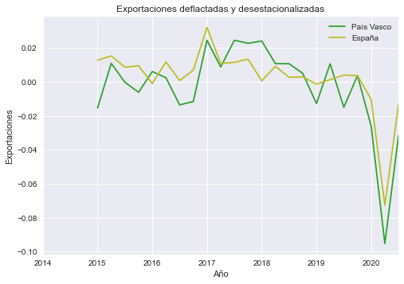

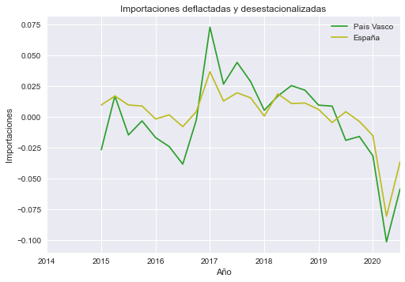

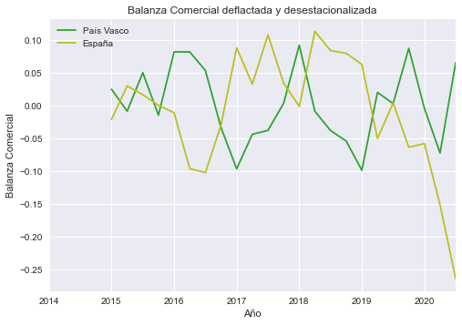

El comercio exterior en el País Vasco es muy similar a las variaciones que suceden en España, aunque observando la balanza comercial del último trimestre nos da indicios de que el comercio exterior para la comunidad autónoma del País Vasco ha tenido una mejor recuperación que el resto de España.

Ahora veamos las ratios de exportaciones e importaciones:

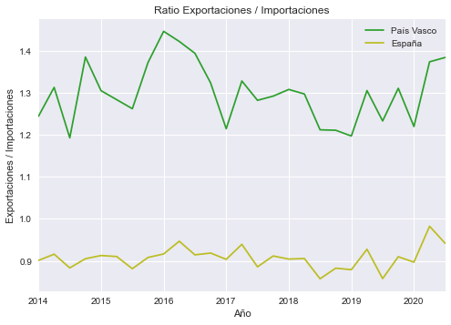

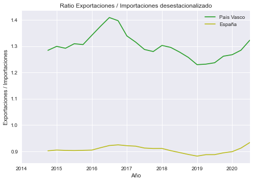

Los resultados obtenidos muestran la diferenciación vasca con su comercio exterior siendo una comunidad la cual su comercio exterior es estable y especialmente alto, es decir, posee un mercado muy competitivo, respecto al resto del país.

## Mercado de Trabajo

En el mercado laboral vamos a estudiar la tasa de actividad, empleo, desempleo y temporalidad desagregadas por sexo.

Además, la evolución de las afiliaciones a la Seguridad Social y el desempleo registrado total. Todo ello comparándolo con los datos nacionales.

#### ·Tasa de actividad

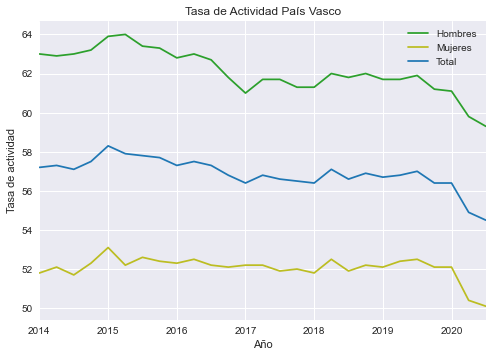

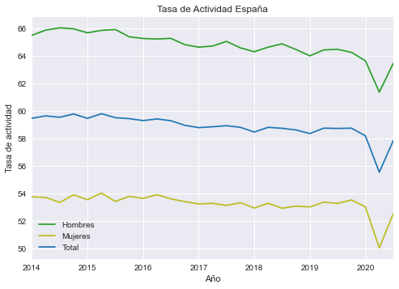

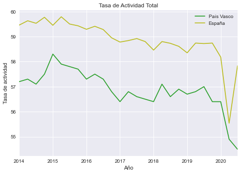

En los dos primeros gráfico se observan las tasas de actividad del País Vasco y España, respectivamente. En el último, comparándo la tasa de actividad vasca, vemos que es contundentemente baja respecto a España.

Esto indica que hay más población inactiva, relativamente hablando, que en la media española.

#### ·Tasa de ocupación

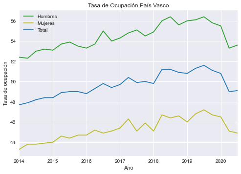

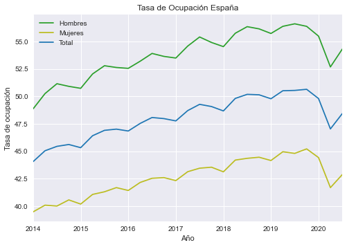

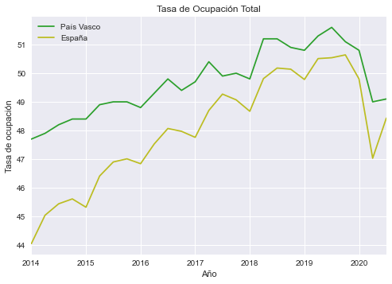

La tasa de ocupación, a diferencia de la tasa de actividad, es bastante similar, siendo incluso relativamente mayor que España.

Esto resulta extraño viendo la dada baja tasa de actividad observada, pero a continuación, con la tasa de paro, veremos por qué sucede.